# R-Ladies Aurora - Introduction to R Functions

Zhixin Lun, PhD

10-01-2024

### Why Function is Recommended?

- Avoid repeating copy-and-paste operation in code
- Reuse code and increase the coding efficiency
- Make your code structure neat by keeping the same and multiple actions on different inputs

### When Should You Write a Function?

Whenever you’ve copied and pasted a block of code more than twice!!!

### Understand function structure:

- Function name
- Argument/Input
- Output

When you started with `library(ggplot2)`, you were actually using R function:

- Function name = `library`
- Argument/Input = `ggplot2`
- Output: the package `ggplot2` gets loaded into your R environment

The form of the function output can be various and depending on your need:

- values (common)
- messages/texts (common)
- figures
- combined list of values and texts
- invisible actions such as loading package

### ‘Easy’ function

The idea of function in programming was motivated by avoiding repeated calculation Let’s start with a simple calculation task for converting temperature to a different unit. The formula for converting the temperature in Fahrenheit ($F$) to Celsius ($C$) is:
$$\text{C} = (\text{F} - 32) \times
\frac{5}{9}$$
The following example code is not a good way to implement the calculation. If we have longer length for `F_vec` (like 1000 elements), should we copy and paste many times? The answer is NO!

```r
F_vec = c(100, 105, 110, 115)
C_vec = rep(4, 0)

# Duplicated operations
C_vec[1] = (F_vec[1] - 32)*5/9
C_vec[2] = (F_vec[2] - 32)*5/9
C_vec[3] = (F_vec[3] - 32)*5/9
C_vec[4] = (F_vec[4] - 32)*5/9

print(C_vec)
```

```
## [1] 37.77778 40.55556 43.33333 46.11111
```

Let’s start with a function:

```r
f_to_c <- function(f_value) {
  c_value = (f_value - 32)*5/9
  return(c_value)
}
```

- Function name = `f_to_c`
- Argument/Input = `f_value`
- Output = the value of `c_value`

Question: do you observe any change in your R Environment after running the above code?

Testing is the first step after writing a function. Pick some values to test the output.

```r
# Test your function
f_to_c(105)
```

```
## [1] 40.55556
```

```r
f_to_c(85)
```

```
## [1] 29.44444
```

```r
f_to_c(65)
```

```
## [1] 18.33333
```

```r
f_to_c(45)
```

```
## [1] 7.222222
```

```r
f_to_c("Hello") # R could handle some basic mistakes for input
```

```
## Error in f_value - 32: non-numeric argument to binary operator
```

If the function is ready, we can apply it on any input.

```r
# Test your function
C_vec = sapply(F_vec, FUN=f_to_c)
print(C_vec)
```

```
## [1] 37.77778 40.55556 43.33333 46.11111
```

```r
# Create 1000 elements
F_vec = seq(1, 1000)
C_vec = sapply(F_vec, FUN=f_to_c)
```

### Understand local and global variables

```r
current_temp_F = 100
current_temp_C = 38
```

**Question**: do you observe any change in your R Environment after running the above code?

- **Global variable**: The assignment is done in the main environment or outside the chunk of function. Both `current_temp_F` and `current_temp_C` are global variables.
- **Local variable**: The assignment is done inside the chunk of function and it is not displayed in the R Global Environment. Both `f_value` and `c_value` are local variables as they were assigned with values inside the function.

#### Mistake 1: Attempting to change the global variable inside a function

```r
f_to_c_mtk <- function(f_value) {
  current_temp_C = (f_value - 32)*5/9
}

f_to_c_mtk(85)
print(current_temp_C)
```

```
## [1] 38
```

```r
f_to_c_mtk(65)
print(current_temp_C)
```

```
## [1] 38
```

```r
f_to_c_mtk(45)
print(current_temp_C)
```

```
## [1] 38
```

The variable `current_temp_C` does not change with the input of `f_value` as `current_temp_C` is a global variable. The operation inside the function does not impact global variables. What should you do if you want to change global variables?

**Answer**: return a value from the function and assign it to global variables.

Here is the correct way for global variable assignment:

```r
f_to_c_corr <- function(f_value) {
  c_value = (f_value - 32)*5/9
  return(c_value)
}

current_temp_C = f_to_c_corr(85)
print(current_temp_C)
```

```
## [1] 29.44444
```

```r
current_temp_C = f_to_c_corr(65)
print(current_temp_C)
```

```
## [1] 18.33333
```

```r
current_temp_C = f_to_c_corr(45)
print(current_temp_C)
```

```
## [1] 7.222222
```

**Tips**: Local variables and global variables shouldn’t share the same names. It is not good for debugging and it also makes your code less readable.

### ‘Moderate’ Function

Let’s make a function with little bit complicated logic inside. Sometimes, you would like to add some limitations on your input. We call it as conditional execution. We continue the previous example for temperature conversion but we limit the input range for human only (91.8-100.8 F).

```r
f_to_c_human <- function(f_value) {

  if (f_value >= 91.8 & f_value <= 100.8) {
    c_value = (f_value - 32)*5/9
    return(c_value)
  }
  else {
    message("Too low or too high!!")
  }
}
```

```r
my_current_temp_C = f_to_c_human(99.8)
my_current_temp_C
```

```
## [1] 37.66667
```

```r
my_current_temp_C = f_to_c_human(1000)
```

```
## Too low or too high!!
```

```r
my_current_temp_C
```

[output not shown]

We can add one more `if` to have a further condition execution.

```r
f_to_c_human_msg <- function(f_value) {

  if (f_value >= 91.8 & f_value <= 100.8) {
    c_value = (f_value - 32)*5/9
    return(c_value)
  }
  else if (f_value < 91.8) {
    message("Too low!!")
  }
  else {
    message("Too high!!")
  }

}
```

```r
my_current_temp_C = f_to_c_human_msg(99.8)
my_current_temp_C
```

```
## [1] 37.66667
```

```r
my_current_temp_C = f_to_c_human_msg(1000)
```

```
## Too high!!
```

```r
my_current_temp_C = f_to_c_human_msg(0)
```

```
## Too low!!
```

**Question**: do you notice the value returned for `my_current_temp_C` is `NULL`. Can you explain why?

### Error Control.

Before talking about error control, let’s have a look at another mistake which is easy to make by beginners.

#### Mistake 2: Variables get changed due to errors.

```r
my_current_temp_C = 37 # initial value
print(my_current_temp_C)
```

```
## [1] 37
```

```r
my_current_temp_C = f_to_c_human(1000)
```

```
## Too low or too high!!
```

```r
print(my_current_temp_C)
```

[output not shown]

**Question**: do you observe that the value of `my_current_temp_C` got changed from `37` to `NULL`?

If you don’t want to reset the variable due to error, you need to control the error. You can consider modifying your function as:

```r
f_to_c_human_stop <- function(f_value) {

  if (f_value >= 91.8 & f_value <= 100.8) {
    c_value = (f_value - 32)*5/9
    return(c_value)
  }
  else if (f_value < 91.8) {
    stop("Too low!!") # stop the function
  }
  else {
    stop("Too high!!") # stop the function
  }
}
```

```r
my_current_temp_C = 37 # initial value

my_current_temp_C = f_to_c_human_stop(99.8)
print(my_current_temp_C)
```

```
## [1] 37.66667
```

```r
my_current_temp_C = f_to_c_human_stop(1000)
```

```
## Error in f_to_c_human_stop(1000): Too high!!
```

```r
print(my_current_temp_C)
```

```
## [1] 37.66667
```

- `stop`: it stops the function but no return for the output.
- `message`: it keeps the function running and returns `NULL` for the output.

Let’s apply these two different error control mechanisms on a vector. We’ll see the difference.

```r
F_vec = c(100, 105, 110, 115)
C_vec = rep(4, 0) # initial values with 0s

C_vec = sapply(F_vec, FUN = f_to_c_human_msg)
```

```
## Too high!!
## Too high!!
## Too high!!
```

```r
print(C_vec)
```

```
## [[1]]
## [1] 37.77778
##
## [[2]]
## NULL
##
## [[3]]
## NULL
##
## [[4]]
## NULL
```

```r
C_vec = rep(4, 0) # initial values with 0s
C_vec = sapply(F_vec, FUN = f_to_c_human_stop)
```

```
## Error in FUN(X[[i]], ...): Too high!!
```

```r
print(C_vec)
```

```
## numeric(0)
```

### You Don’t Need to Reinvent the Wheel!

Before starting to write a new function, try to explore if there are some existing functions or packages in R. If not, then create your own functions.

For an example, we would like to plot histogram for each numeric columns for the dataset `iris`.

```r
library(knitr)
library(vtable)

head(iris, n = 50) %>%
  kable %>%
  kable_styling("striped", full_width = F) %>%
  scroll_box(height = "200px")
```

| Sepal.Length | Sepal.Width | Petal.Length | Petal.Width | Species |
| --- | --- | --- | --- | --- |
| 5.1 | 3.5 | 1.4 | 0.2 | setosa |
| 4.9 | 3.0 | 1.4 | 0.2 | setosa |
| 4.7 | 3.2 | 1.3 | 0.2 | setosa |
| 4.6 | 3.1 | 1.5 | 0.2 | setosa |
| 5.0 | 3.6 | 1.4 | 0.2 | setosa |
| 5.4 | 3.9 | 1.7 | 0.4 | setosa |
| 4.6 | 3.4 | 1.4 | 0.3 | setosa |
| 5.0 | 3.4 | 1.5 | 0.2 | setosa |
| 4.4 | 2.9 | 1.4 | 0.2 | setosa |
| 4.9 | 3.1 | 1.5 | 0.1 | setosa |
| 5.4 | 3.7 | 1.5 | 0.2 | setosa |
| 4.8 | 3.4 | 1.6 | 0.2 | setosa |
| 4.8 | 3.0 | 1.4 | 0.1 | setosa |
| 4.3 | 3.0 | 1.1 | 0.1 | setosa |
| 5.8 | 4.0 | 1.2 | 0.2 | setosa |
| 5.7 | 4.4 | 1.5 | 0.4 | setosa |
| 5.4 | 3.9 | 1.3 | 0.4 | setosa |
| 5.1 | 3.5 | 1.4 | 0.3 | setosa |
| 5.7 | 3.8 | 1.7 | 0.3 | setosa |
| 5.1 | 3.8 | 1.5 | 0.3 | setosa |
| 5.4 | 3.4 | 1.7 | 0.2 | setosa |
| 5.1 | 3.7 | 1.5 | 0.4 | setosa |
| 4.6 | 3.6 | 1.0 | 0.2 | setosa |
| 5.1 | 3.3 | 1.7 | 0.5 | setosa |
| 4.8 | 3.4 | 1.9 | 0.2 | setosa |
| 5.0 | 3.0 | 1.6 | 0.2 | setosa |
| 5.0 | 3.4 | 1.6 | 0.4 | setosa |
| 5.2 | 3.5 | 1.5 | 0.2 | setosa |
| 5.2 | 3.4 | 1.4 | 0.2 | setosa |
| 4.7 | 3.2 | 1.6 | 0.2 | setosa |
| 4.8 | 3.1 | 1.6 | 0.2 | setosa |
| 5.4 | 3.4 | 1.5 | 0.4 | setosa |
| 5.2 | 4.1 | 1.5 | 0.1 | setosa |
| 5.5 | 4.2 | 1.4 | 0.2 | setosa |
| 4.9 | 3.1 | 1.5 | 0.2 | setosa |
| 5.0 | 3.2 | 1.2 | 0.2 | setosa |
| 5.5 | 3.5 | 1.3 | 0.2 | setosa |
| 4.9 | 3.6 | 1.4 | 0.1 | setosa |
| 4.4 | 3.0 | 1.3 | 0.2 | setosa |
| 5.1 | 3.4 | 1.5 | 0.2 | setosa |
| 5.0 | 3.5 | 1.3 | 0.3 | setosa |
| 4.5 | 2.3 | 1.3 | 0.3 | setosa |
| 4.4 | 3.2 | 1.3 | 0.2 | setosa |
| 5.0 | 3.5 | 1.6 | 0.6 | setosa |
| 5.1 | 3.8 | 1.9 | 0.4 | setosa |
| 4.8 | 3.0 | 1.4 | 0.3 | setosa |
| 5.1 | 3.8 | 1.6 | 0.2 | setosa |
| 4.6 | 3.2 | 1.4 | 0.2 | setosa |
| 5.3 | 3.7 | 1.5 | 0.2 | setosa |
| 5.0 | 3.3 | 1.4 | 0.2 | setosa |

First, let’s create a histogram for the variable `Sepal.Length` by different `Species`.

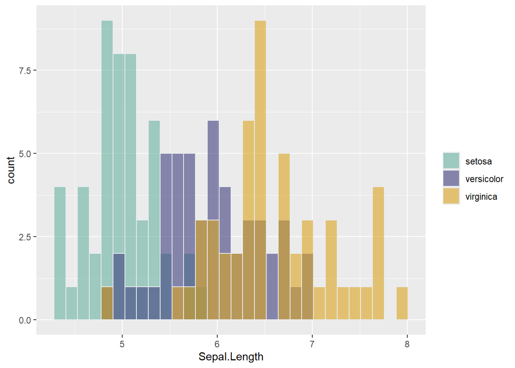

```r
library(ggplot2)
library(dplyr)

iris %>%
  ggplot(aes(x=Sepal.Length, fill=Species)) +
  geom_histogram(color="#e9ecef", alpha=0.6, position = 'identity') +
  scale_fill_manual(values=c("#69b3a2", "#404080", "goldenrod")) +
  labs(fill="")
```

Instead of copying and pasting the above block of lines **3 times** for the other columns (`Sepal.Width`, `Petal.Length`, and `Petal.Width`), we can define a function with `input = numeric variables` and `output = figure`.

```r
iris_hist <- function(iris_data, iris_var) {
  iris_data %>%
  ggplot(aes(x={{iris_var}}, fill=Species)) +
  geom_histogram(color="#e9ecef", alpha=0.6, position = 'identity') +
  scale_fill_manual(values=c("#69b3a2", "#404080", "goldenrod")) +
  labs(fill="")
}
```

**Importance**: `{{` (read: curly curly) tells R to treat the variable as a data frame variable.

Call the function with different inputs:

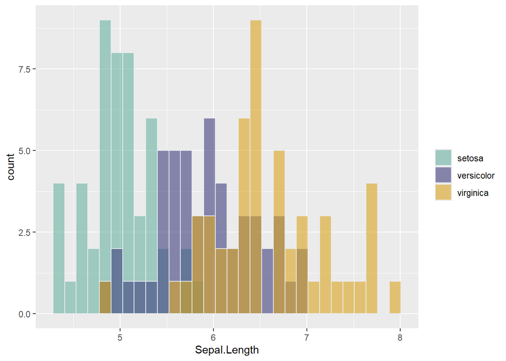

```r
iris_hist(iris, Sepal.Length)
```

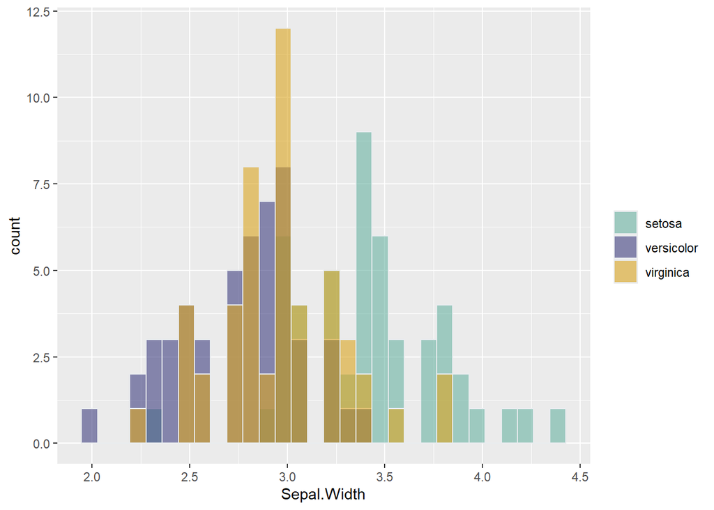

```r
iris_hist(iris, Sepal.Width)
```

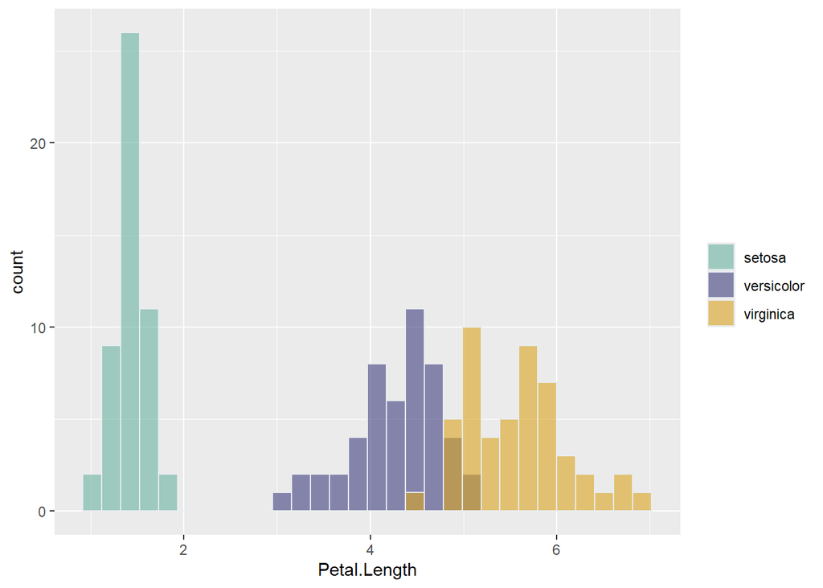

```r
iris_hist(iris, Petal.Length)
```

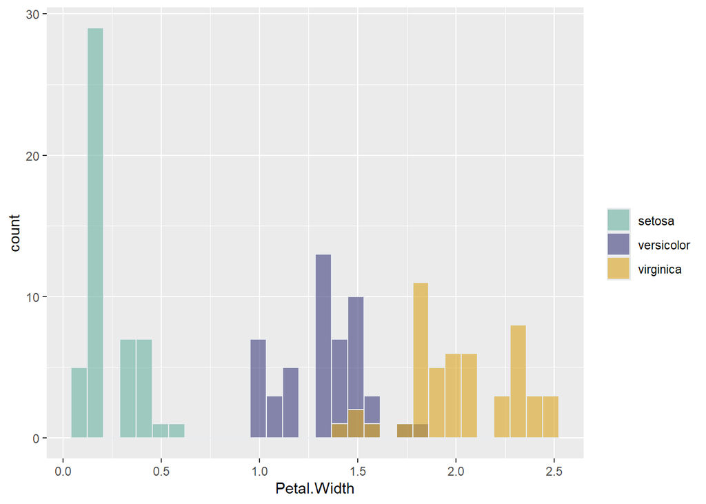

```r
iris_hist(iris, Petal.Width)
```

### Good Practices

**Writing a function:**

- Function names: verbs, never start with numbers. Consider using underscores to separate words, e.g., `impute_missing()`, `calc_avg()`.
- Argument names: nouns
- Output: explicitly return values or messages using `return()` and `message()`.

**Calling a function:**

- Make your code more readable by explicitly assigning values for arguments

```r
# Good
mean(x = 1:10, na.rm = TRUE)
```

```
## [1] 5.5
```

```r
# Not so good:
mean(1:10, ,TRUE)
```

```
## [1] 5.5
```